# The laws of migration

Ilya Kashnitsky

05 December 2016

# The initial push

# William Farr

[figure not shown]

*“…migration appeared to go on without any definite law…”*

# Ernst Georg Ravenstein

[figure not shown]

# The papers

Ravenstein, E. G. (1885). The Laws of Migration. *Journal of the Statistical Society of London*, 48(2), 167-235. https://doi.org/10.2307/2979181

Ravenstein, E. G. (1889). The Laws of Migration. *Journal of the Royal Statistical Society*, 52(2), 241-305. https://doi.org/10.2307/2979333

# Everett Lee

Lee, E. S. (1966). A theory of migration. *Demography*, 3(1), 47-57. https://doi.org/10.2307/2060063

One of the most influential papers in migration studies

- Summarized Ravenstein’s “Laws” (now it is common to name them Revnstein-Lee laws)
- Formulated the Theory of Migration
- Propesed hypotheses to study based on the theory
1. Migration and distance
2. Migration by stage
3. Stream and counter-stream
4. Urban-rural differences in propensity to migrate
5. Predominance of females among short-distance migrants
6. Technology and migration
7. Dominance of the economic motive

# Migration laws in Ravenstein’s words

# 1. Migration and distance

- *(a) “[T]he great body of our migrants only proceed a short distance” and “migrants enumerated in a certain center of absorption will … grow less [as distance from the center increases]” (I, pp. 198-99)*
- *(b) “Migrants proceeding long distances generally go by preference to one of the great centers of commerce and industry” (I, p. 199)*

# 2. Migration by stage

- *(a) “[T]here takes place consequently a universal shifting or displacement of the population, which produces ‘currents of migration,’ setting in the direction of the great centers of commerce and industry which absorb the migrants” (I, p.198)*
- *(b) “The inhabitants of the country immediately surrounding a town of rapid growth flock into it; the gaps thus left in the rural population are filled up by migrants from more remote districts, until the attractive force of one of our rapidly growing cities makes its influence felt, step by step, to the most remote corner of the kingdom” (I, p. 199)*
- *(c) “The process of dispersion is the inverse of that of absorption, and exhibits similar features” (I, p. 199)*

# 3. Stream and counterstream

- *“Each main current of migration produces a compensating counter-current” (I, p. 199)*

# 4. Urban-rural differences in propensity to migrate

- *“The natives of towns are less migratory than those of the rural parts of the country” (I, p. 199)*

# 5. Predominance of females among short-distance migrants

- *“Females appear to predominate among short-journey migrants” (II, p.288)*

# 6. Technology and migration

- *“Does migration increase? I believe so! … Wherever I was able to make a comparison I found that an increase in the means of locomotion and a development of manufactures and commerce have led to an increase of migration” (II, p. 288)*

# 7. Dominance of the economic motive

- *“Bad or oppressive laws, heavy taxation, an unattractive climate, uncongenial social surroundings, and even compulsion (slave trade, transportation), all have produced and are still producing currents of migration, but none of these currents can compare in volume with that which arises from the desire inherent in most men to ‘better’ themselves in material respects” (II, p. 286)*

# Lee’s theory

# Factors in the act of migration

1. Factors associated with the area of origin.
2. Factors associated with the area of destination.
3. Intervening obstacles.
4. Personal factors.

# Hypotheses based on the theory

# Volume of migration

1. The volume of migration within a given territory varies with the degree of diversity of areas included in that territory
2. The volume of migration varies with the diversity of people
3. The volume of migration is related to the difficulty of surmounting the intervening obstacles
4. The volume of migration varies with fluctuations in the economy
5. Unless severe checks are imposed, both volume and rate of migration tend to increase with time
6. The volume and rate of migration vary with the state of progress in a country or area

# Stream and counterstream

1. Migration tends to take place largely within well defined streams
2. For every major migration stream, a counterstream develops
3. The efficiency of the stream (ratio of stream to counterstream or the net redistribution of population effected by the opposite flows) is high if the major factors in the development of a migration stream were minus factors at origin
4. The efficiency of stream and counterstream tends to be low if origin and destination are similar
5. The efficiency of migration streams will be high if the intervening obstacles are great
6. The efficiency of a migration stream varies with economic conditions, being high in prosperous times and low in times of depression

# Characteristics of migrants

1. Migration is selective
2. Migrants responding primarily to plus factors at destination tend to be positively selected
3. Migrants responding primarily to minus factors at origin tend to be negatively selected; or, where the minus factors are overwhelming to entire population groups, they may not be selected at all
4. Taking all migrants together, selection tends to be bimodal
5. The degree of positive selection increases with the difficulty of the intervening obstacles
6. The heightened propensity to migrate at certain stages of the life cycleis important in the selection of migrants
7. The characteristics of migrants tend to be intermediate between the characteristics of the population at origin and the population at destination

# The volume internal of migration

Bell, M., Charles-Edwards, E., Ueffing, P., Stillwell, J., Kupiszewski, M., & Kupiszewska, D. (2015). Internal Migration and Development: Comparing Migration Intensities Around the World. Population and Development Review, 41(1), 33-58. https://doi.org/10.1111/j.1728-4457.2015.00025.x

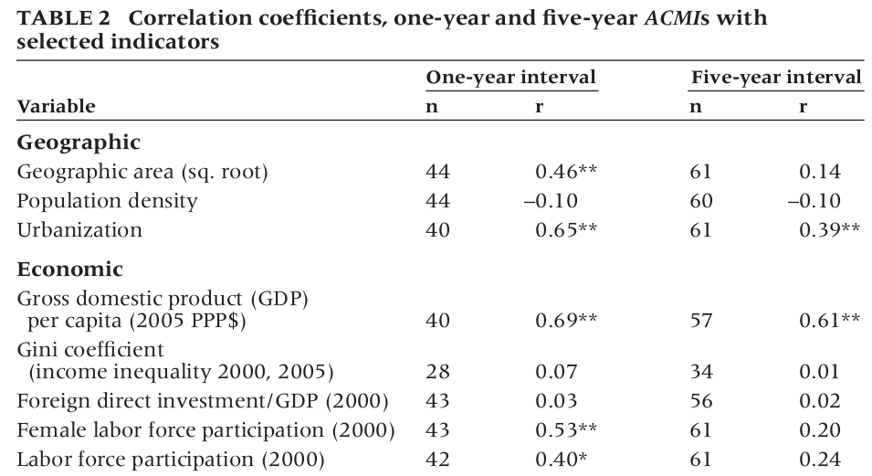

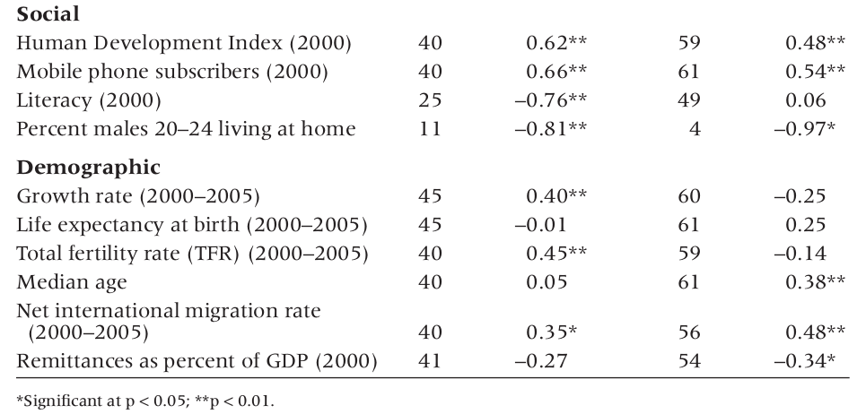

# Most migrants move only a short distance

Stillwell, J., & Thomas, M. (2016). How far do internal migrants really move? Demonstrating a new method for the estimation of intra-zonal distance. *Regional Studies, Regional Science*, 3(1), 28-47. https://doi.org/10.1080/21681376.2015.1109473

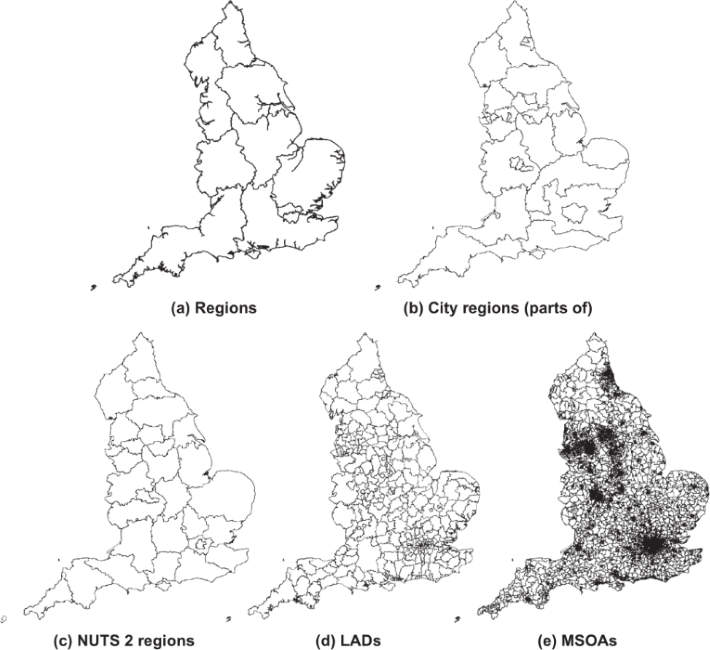

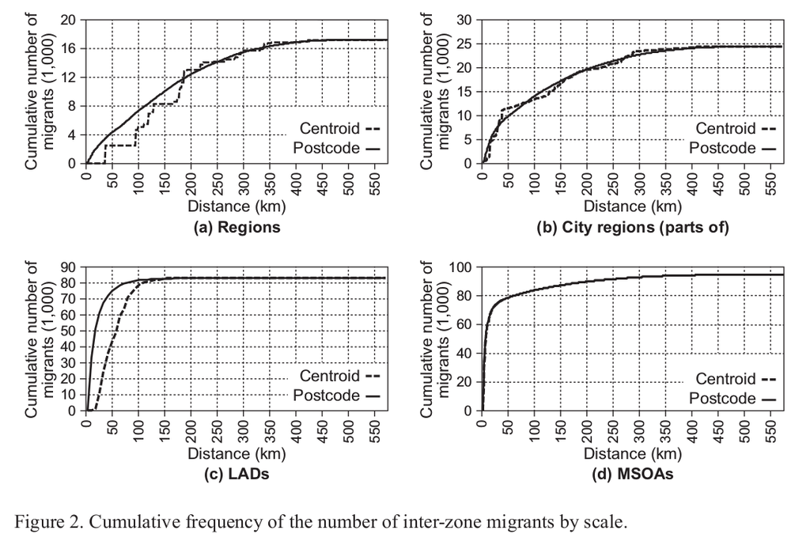

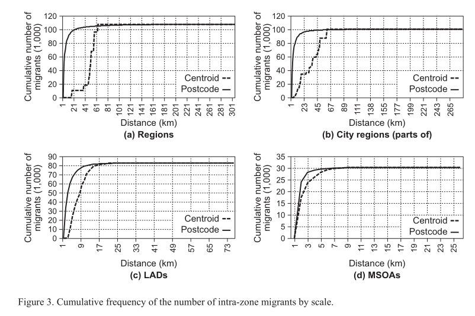

Kashnitsky, I., & Gunko, M. (2016). Spatial variation of in-migration to Moscow: testing the effect of housing market. *Cities*. https://doi.org/10.1016/j.cities.2016.05.025

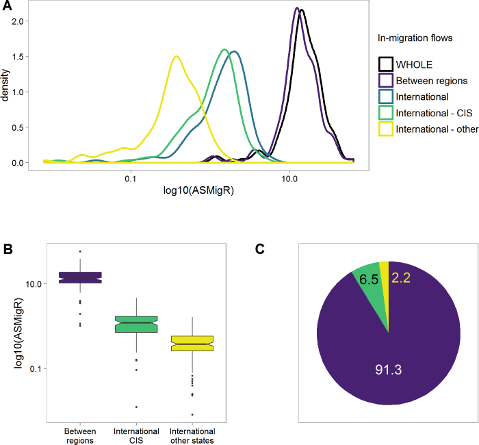

# Selectiveness of migration

Age structure of London

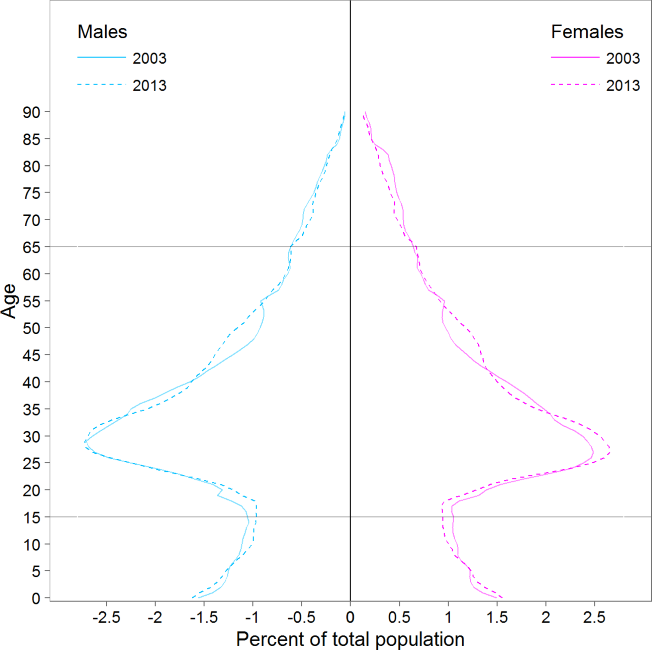

Kashnitsky, I., & Mkrtchyan, N. (2014). Russian periphery is dying in movement: a cohort assessment of Russian internal youth migration based on Census data. NIDI Working Papers, 2014/14. Retrieved from www.nidi.nl/shared/content/output/papers/nidi-wp-2014-14.pdf

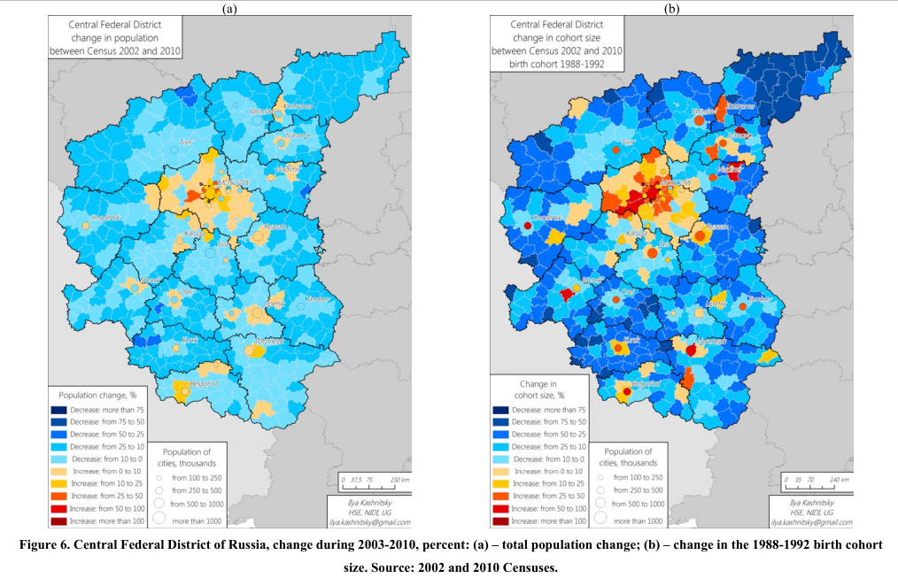

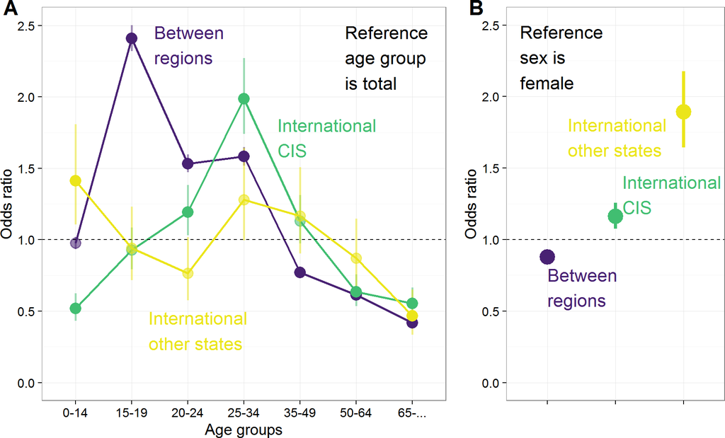

Kashnitsky, I., & Gunko, M. (2016). Spatial variation of in-migration to Moscow: testing the effect of housing market. *Cities*. https://doi.org/10.1016/j.cities.2016.05.025

# Exercise

https://github.com/ikashnitsky/hse-migr-laws

`exercise-selectiveness-of-migration.R`

Urban/rural differences in population stuctures of the US counties

# Adult sex ratio (15-44yo)

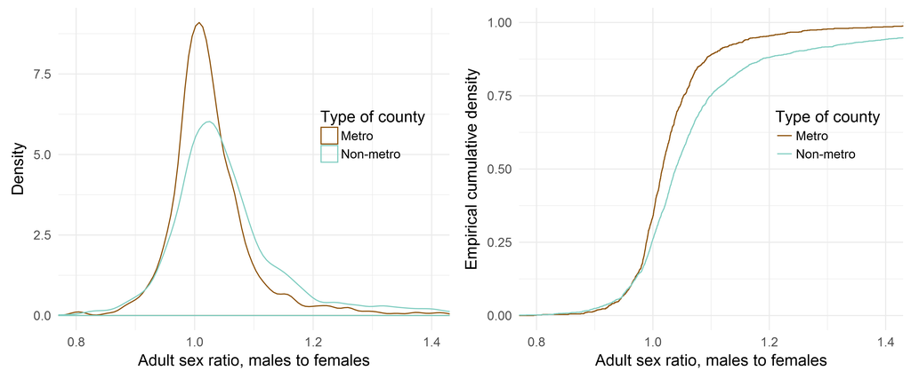

# Median age

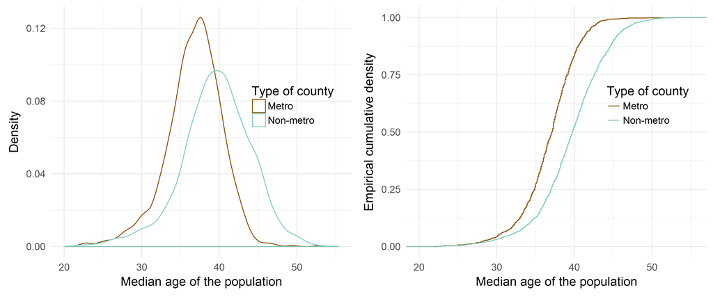